# Exploring the Visual Nature of London Urban Development with Convolutional Neural Networks

- Companion Python Code for Dissertation Submission (MRes in Spatial Data Science and Visualisation - Bartlett UCL 2017)
- Presentation version of the Jupyter Script Workflows (inc Explanatory notes, Screenshots and Clipped Cell Output for notebook size reduction)
- Raw Code is available in a seperate folder

# Workflow 1 - Data Model Build and Exploration

## Aim

- Setting the Scene - What Does New London Look Like?
- Introducing Research Themes: Visualising Urban Change with Aggregate Real Time London Visual Building Data > Using Machine Learning to understand macro level phenomena> Public Enfranchisement > Digital Property Cadastre
- Introducing the Datasets(OS AddressBase, OpenStreetMap, GLA's London Development Database)
- Exploring Potential Data Models
- Augmenting our Data Model with Auxiliary Investigative Threads (CACI Acorn GeoDemographic Classes, London Ward and Borough Census, MIT Place Pulse Crowdsource Project(Cognitive/Psychological), TFL PTAL Zones, Town Planning Use Classes, New London vs Old London)
- Quick Spin Tensorflow CNN Trainer for Identifying Suitable Candidate Image Datasets for CNN Image Classification Task
- Additional Holoviz, DataShader and Processing 3 Data Model Exploration
- Building the Final Data Model

# Method

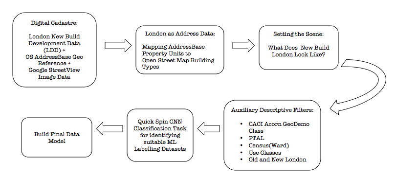

### Setup

```python
## Load Librarys and Jupyter User Settings
from IPython.core.display import display, HTML
display(HTML("<style>.container { width:760 !important; }</style>"))
#Run Multiple Commands in One Cell
from IPython.core.interactiveshell import InteractiveShell
InteractiveShell.ast_node_interactivity = "all"
#Get All DataFrame Columns
import pandas as pd
pd.set_option('display.max_colwidth', -1)
import numpy as np
pd.set_option('display.max_columns', None)
import matplotlib.pyplot as plt
from IPython.display import Markdown, display, HTML
from IPython.display import Image as Img
import seaborn as sns

#%matplotlib inline
```

```python
## Table Plotting Functions
def plotdat(data,cat):
    #Set Min Number of Records
    data = data.groupby('ClassificationCode').filter(lambda x : len(x)>5)
    l=data.groupby(cat).size()
    l.sort_values()
    fig=plt.figure(figsize=(20,5))
    plt.yticks(fontsize=8)
    l.plot(kind='bar',fontsize=12,color='k')
    plt.xlabel('',)
    plt.ylabel('Number of ...',fontsize=10)
    plt.show()

## Table Label Helper
def printmd(string):
    display(Markdown(string))
```

```python
# Widgets
from __future__ import print_function
from ipywidgets import interact, interactive, fixed, interact_manual, Layout, Button
import ipywidgets as widgets
```

# 1 - What are we Building in London?

- Open Source Future, Here and Now: Creating a Digital Cadstre & Visual Property Ledger for London

#### Load London Development Database

```python
#Load CSV
#Includes stripping for NULLs
df_ldd = pd.read_csv('/Users/anthonysutton/ml2/_DATA_LABELS/LDD_STORE/LDD_MODEL/AB_LDD.csv',  sep=',',
                           error_bad_lines=False, index_col=False,  na_values=['.'], encoding="ISO-8859-1")

#Occasional Second Clean up required with these large python created csvs:
df_ldd.dropna()

#Visual Check of DataFrame:
# Just get the cells of interest:
 df_ldd[['TempID', 'Resi_Site_Prop_ha','Non_Resi_Site_Prop_ha','Total_Open_ Space_Exist_ha',
               'Total_Open_ Space_Prop_ha', 'Total_Site_Area_Prop_ha', 'Existing_Total_Residential_Units',
               'Proposed_Total_Residential_Units','Proposed_TotalAffordable_Units','Proposed_Total_Affordable_Percentage',
               'Proposed_Residential_Parking_Spaces','Cash_in_Lieu_Affordable_Housing','Existing_Total_Bedrooms',
                   'Proposed_Total_Bedrooms', 'Existing_Total_Floorspace', 'Proposed_Total_Floorspace',
               'ClassificationCode','Latitude','Longitude','Developmen', 'Primary_St', 'Site_Name_']].head(10)


printmd('<br><b>`The LDD Master Dataset`</b> &#9663;<br><br>')
df_ldd.shape
df_ldd.head(1)
```

**`The LDD Master Dataset`** ▿

```
(66284, 93)
```

|  | UQ_ID | OBJECTID | TempID | Point_X | Point_Y | F1 | Planning_A | Borough_Re | Current_pe | Permission | Decision_A | Developmen | Scheme_Nam | Site_Name_ | Subdivisio | Primary_St | Secondary | Post_Code | Ward | Easting | Northing | Permissi_1 | Permissi_2 | Date_work | Started_Fi | Date_const | Completed | Date_permi | Lapsed_Fin | … |
| --- | --- | --- | --- | --- | --- | --- | --- | --- | --- | --- | --- | --- | --- | --- | --- | --- | --- | --- | --- | --- | --- | --- | --- | --- | --- | --- | --- | --- | --- | --- |
| 0 | 1 | 346 | 4187 | 552961 | 177195 | 4188 | Bexley | 14/00238/FUL | Completed | Full | Borough | Two storey side extension to provide a one bedroom annexe |  | Lower Farm |  | Wallhouse Road |  | DA8 2JY | NORTH END | 552961 | 177195 | 2.010000e+13 | FY2014 | 2.020000e+13 | FY2015 | 2.020000e+13 | FY2016 | 2.020000e+13 | FY2017 | … |

### Note on Georeferencing the Dataset

> - Special Thanks to E Gondugollu & LB Tower Hamlets GIS Department
> - OS AddressBase Data acquisition, BNG to Lat Lon Conversion, Address Validation, Street Name & Numbering Info, ESRI SDE Spatial Buffer Join

# What are we interested in?

- Development Total vs Unit Totals
- Completion Rate and Ratio
- Development Sizes
- Areal Density
- Affordability
- Yearly, Local & National Comparisions

**`Number of Properties Built Since 2004 By Borough`** ▿

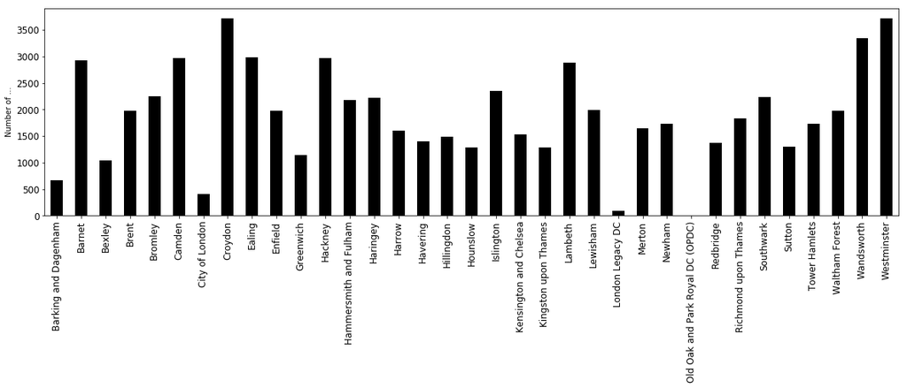

```python
printmd('<br><b>`Number of Properties Built Since 2004 By Borough`</b> &#9663;<br><br>')
plotdat(df_ldd,'Planning_A')
```

**`London Aggregated Property Count Since 2004 By Year`** ▿

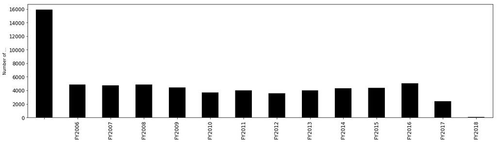

```python
printmd('<br><b>`London Aggregated Property Count Since 2004 By Year`</b> &#9663;<br><br>')
plotdat(df_ldd,'Completed')
```

**`Building Completions/Non Completions(See Column 1)By Year`** ▿

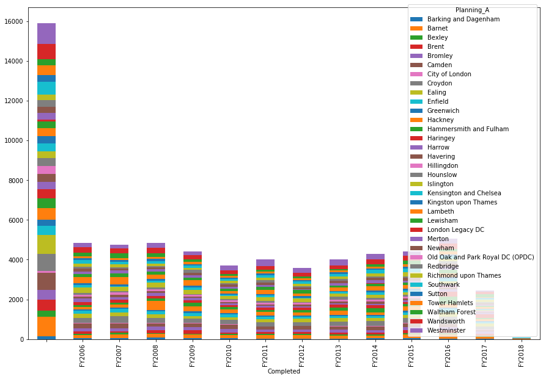

```python
df_filter1 = df_ldd.groupby(['Completed', 'Planning_A'])['Completed'].count().unstack('Planning_A').fillna(0)
printmd('<br><b>`Building Completions/Non Completions(See Column 1)By Year`</b> &#9663;<br><br>')
df_filter1.plot(kind='bar', stacked=True, figsize=(15, 10));
#df_filter1.plot(kind='bar', figsize=(18, 10));
```

**`Building Completions/Non Completions By Year - FY2006`** ▿

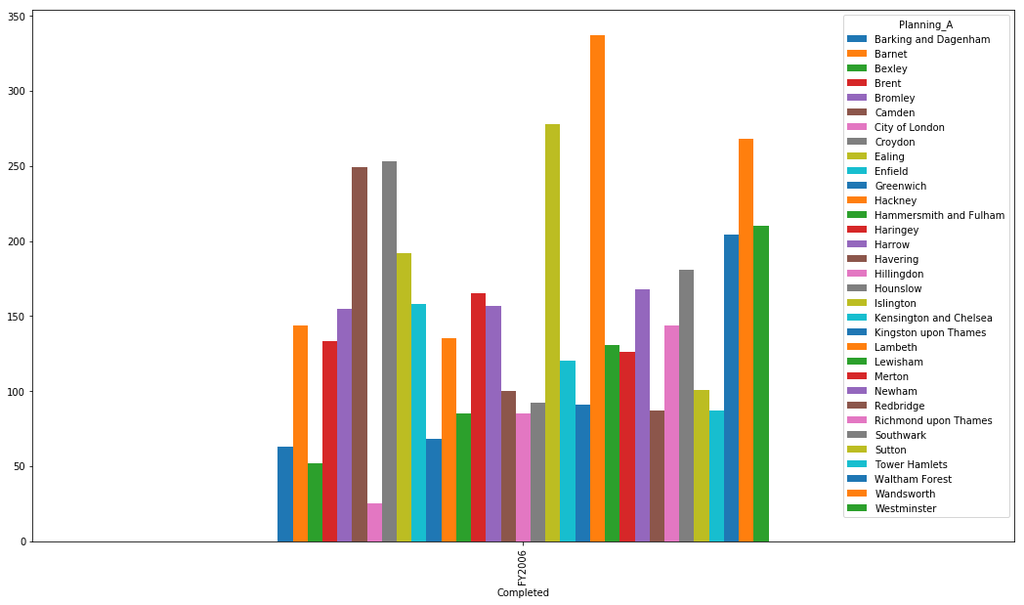

```python
printmd('<br><b>`Building Completions/Non Completions By Year - FY2006`</b> &#9663;<br><br>')
df_filter2 = df_ldd[df_ldd['Completed'] == 'FY2006']
df_filter2 = df_filter2.groupby(['Completed', 'Planning_A'])['Completed'].count().unstack('Planning_A').fillna(0)
df_filter2.plot(kind='bar', figsize=(18, 10));
```

## iPython Widgets - Selection Tool

```python
boro_name = df_ldd.Planning_A.unique()
Borough_Selector =    widgets.SelectMultiple(
    options= boro_name,
    #value='2',
    description='',
    disabled=False,
    rows=10,
    layout=Layout(width='50%', height='100%')
    )
printmd("<div class='alert alert-block alert-info'><b>Select Borough:</b> (ctrl+ for Multiple Select) &#9662;")
display(Borough_Selector)
printmd("</div>")
Borough_Selection = Borough_Selector.value
```

**Select Borough:** (ctrl+ for Multiple Select) ▾

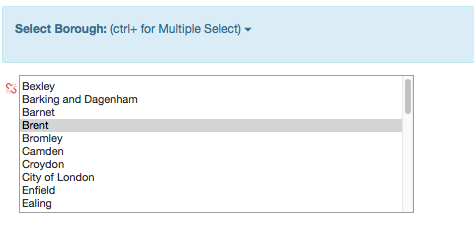

```python
Borough_Selection = Borough_Selector.value
printmd("<div class='alert alert-block alert-info'>You have selected:<b> " + str(Borough_Selection) + "</b></div>")
```

You have selected: **('Brent',)**

**`Building Completions/Non Completions By Year for('Brent',)`** ▿

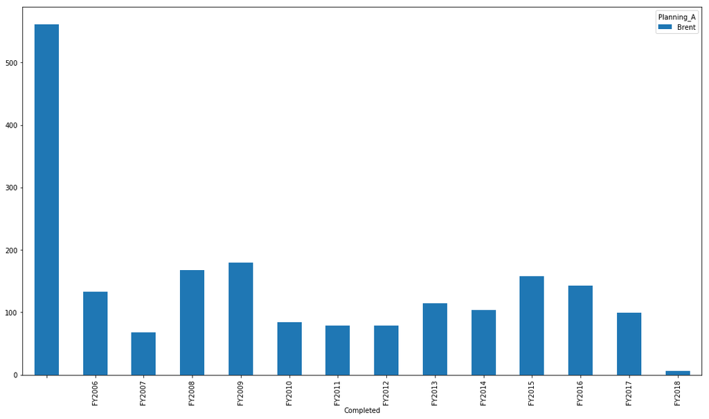

```python
df_filter3 = df_ldd.loc[df_ldd['Planning_A'].isin(Borough_Selection)]
df_filter3 = df_filter3.groupby(['Completed', 'Planning_A'])['Completed'].count().unstack('Planning_A').fillna(0)
printmd('<br><b>`Building Completions/Non Completions By Year for' + str(Borough_Selection) + '`</b> &#9663;<br><br>')
df_filter3.plot(kind='bar', figsize=(18, 10));
```

### Exploring Floorspace, Unit Size + Counts, Density & Affordability in The LDD

**`Building Completion Floorspace`** ▿

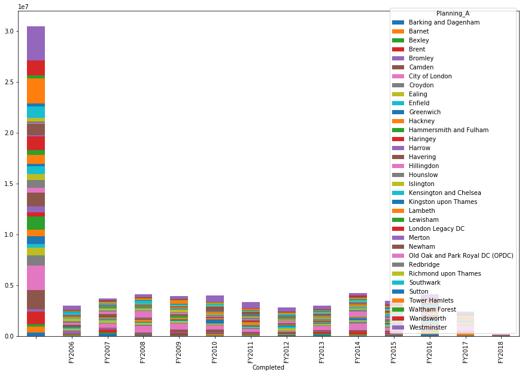

```python
df_filter4 = df_ldd
df_filter4 = df_filter4.groupby(['Planning_A', 'Completed'])['Total_FloorSpace'].sum().unstack('Planning_A').fillna(0)
printmd('<br><b>`Building Completion Floorspace`</b> &#9663;<br><br>')
df_filter4.plot(kind='bar', stacked=True, figsize=(15, 10));
```

### Using Widgets to Explore the Master Data

```python
#Create Widget
ldd_col_name = list(df_ldd.columns.values)
Column_Selector =    widgets.Select(
    options= ldd_col_name,
    #value='2',
    description='',
    disabled=False,
    rows=10,
    layout=Layout(width='50%', height='100%')
    )

printmd("<div class='alert alert-block alert-info'><b>Select Column of Interest:</b>  &#9662;")
display(Column_Selector)
printmd("</div>")
```

**Select Column of Interest:** ▾

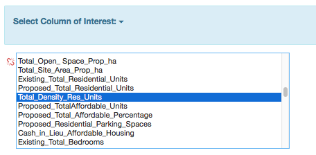

You have selected: **Total_Density_Res_Units**

**` Total_Density_Res_Units`** ▿

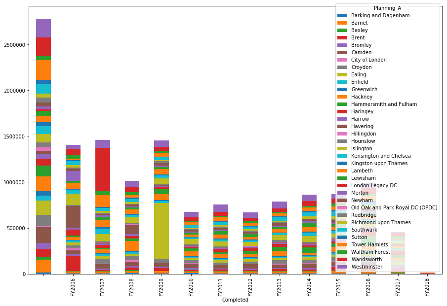

```python
Column_Selection = Column_Selector.value
printmd("<div class='alert alert-block alert-info'>You have selected:<b> " + str(Column_Selection) + "</b></div>")
df_filter_ldd = df_ldd
df_filter_ldd = df_filter_ldd.groupby(['Planning_A', 'Completed'])[str(Column_Selection)].sum().unstack('Planning_A').fillna(0)
printmd('<br><b>` ' + str(Column_Selection) + '`</b> &#9663;<br><br>')
df_filter_ldd.plot(kind='bar', stacked=True, figsize=(15, 10));
```

### Some Observations

- Land Banking, Non Completions
- Luxury vs Affordable > Parking + Cash in Lieu of Affordable
- Houses vs Flats
- Increasing Density > Units & Bedrooms
- Floorspace > Building Upwards

# 2 - Where are we Building in London?

**`X and Y Locations of London New Build Development Since 2004`** ▿

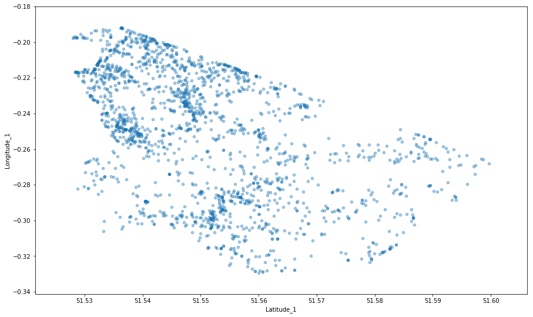

```python
#Filter DF by Selection
df_filter_geo = df_ldd.loc[df_ldd['Planning_A'].isin(Borough_Selection)]
df_filter_geo.shape
printmd('<br><b>`X and Y Locations of London New Build Development Since 2004`</b> &#9663;<br><br>')
plt = df_filter_geo.plot(kind='scatter',x='Latitude_1',y='Longitude_1', alpha=0.4, figsize=(15, 9)); # scatter plot
```

```python
boro_name = df_ldd.Planning_A.unique()
Borough_Selector =    widgets.SelectMultiple(
    options= boro_name,
    #value='2',
    description='',
    disabled=False,
    rows=10,
    layout=Layout(width='50%', height='100%')
    )
printmd("<div class='alert alert-block alert-info'><b>Select Borough:</b> (ctrl+ for Multiple Select) &#9662;")
display(Borough_Selector)
printmd("</div>")
Borough_Selection = Borough_Selector.value
```

**Select Borough:** (ctrl+ for Multiple Select) ▾

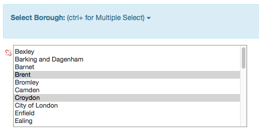

You have selected: **('Brent', 'Croydon', 'Tower Hamlets')**

**`X and Y Locations of London New Build Development Since 2004`** ▿

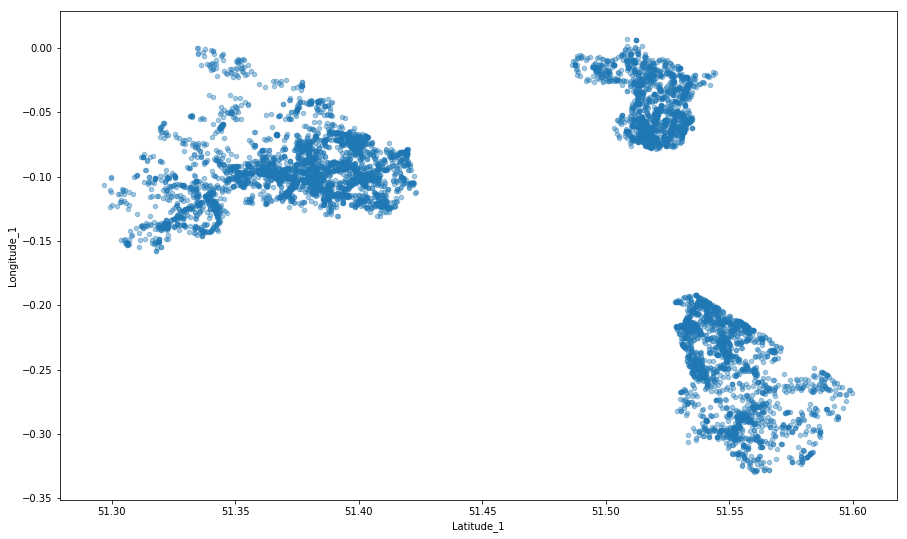

```python
Borough_Selection = Borough_Selector.value
printmd("<div class='alert alert-block alert-info'>You have selected:<b> " + str(Borough_Selection) + "</b></div>")
#Filter DF by Selection
df_filter_geo = df_ldd.loc[df_ldd['Planning_A'].isin(Borough_Selection)]
df_filter_geo.shape
printmd('<br><b>`X and Y Locations of London New Build Development Since 2004`</b> &#9663;<br><br>')
plt = df_filter_geo.plot(kind='scatter',x='Latitude_1',y='Longitude_1', alpha=0.4, figsize=(15, 9)); # scatter plot
```

# 3 - Exploring London Building Typology

### London as Address Data

```python
#Load AddBase Schema CSV
#Includes stripping for NULLs
df_ab_schema = pd.read_csv('LookUps/AB_Schema.csv',  sep=',',
                           error_bad_lines=False, index_col=False,  na_values=['.'], encoding="ISO-8859-1")
#df_ab_schema.shape
#Some Extra Nulls Maybe WhiteSpace Needs Cleaning
#df_ab_schema.dropna()
df_ab_schema.shape

#Join the 2 x tables
df_ldd_ab_sch_join = pd.merge(df_ldd, df_ab_schema, on='ClassificationCode' , how='left')
df_ldd_ab_sch_join.shape
```

```
(563, 11)
```

```
(66284, 103)
```

### Ordnance Survey Addressbase Premium Dataset and Classification Schema

- Intro > How Addresses are Created and Maintained
- SNN Process > Development Process, Local vs National Hub Statutory Function
- Licensing > Open vs Proprietary
- Intro to CNN Training Label Requirements and OSM Fuzzy Chalenges for Script 4/3

```python
#Inspect the OS Address Classfication  Schema
printmd('<br><b>`OS Addressbase Premium Schema Dataset`</b> &#9663;<br><br>')
df_ab_schema.head(1)
```

**`OS Addressbase Premium Schema Dataset`** ▿

|  | Concatenated | ClassificationCode | Class_Desc | Primary_Code | Secondary_Code | Tertiary_Code | Quaternary_Code | Primary_Desc | Secondary_Desc | Tertiary_Desc | Quaternary_Desc |
| --- | --- | --- | --- | --- | --- | --- | --- | --- | --- | --- | --- |
| 0 | C | C | Commercial | C | NaN | NaN | NaN | Commercial | NaN | NaN | NaN |

##### Address Base Schema

- Split into Code, Description
- Use Class orientated schema
- Urban Design: Physical Function vs Physical Form
- Challenges for a CNN Classification Task
- Hierachical Scale: Primary, Secondary, Tertiary, Quaternary classes of address descritptor
- Introduction of Crisp and Fuzzy set matching and membership

```python
##Code LookUp
df_ab_schema["LookUp"] =  df_ab_schema['Concatenated'] +  '----> ' + df_ab_schema['Class_Desc'] \
    +  '----> ' + df_ab_schema['Primary_Desc']

df_ab_sch_slice_np = df_ab_schema.LookUp.unique()
addbase_scheme_Selector =    widgets.Select(
    options= df_ab_sch_slice_np,
    #value='2',
    description='',
    disabled=False,
    rows=10,
    layout=Layout(width='50%', height='100%')
    )
printmd("<div class='alert alert-block alert-success'>Look Up Table for AB Class Schema Descriptions:" +
        "&#9662;")
display(addbase_scheme_Selector)
printmd("</div>")
```

Look Up Table for AB Class Schema Descriptions:▾

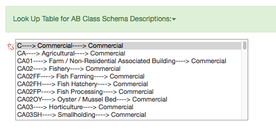

```python
#df_ldd_Filter1 = df_ldd.loc[df_ldd['Planning_A'].isin(Borough_Selection)]
```

##### Inspect Use Class Category Example Size and Distribution of our data selection:

```python
def plotdat_label(data,cat):
    #We need al least 100 Images for the CNN
    data = data.groupby('ClassificationCode').filter(lambda x : len(x)>100)
    l=data.groupby(cat).size()
    l.sort_values()
    fig=plt.figure(figsize=(20,5))
    plt.yticks(fontsize=8)
    l.plot(kind='bar',fontsize=12,color='k')
    plt.xlabel('Property Type',)
    plt.ylabel('Number of ...',fontsize=10)
    plt.show()
```

**`Number and Type of Properties Built Since 2004`** ▿

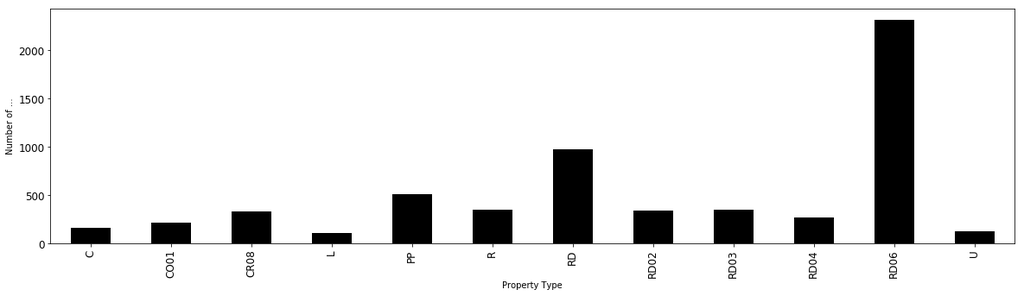

**`Selected Boroughs:('Brent', 'Croydon', 'Tower Hamlets')`**

**`London Wide Comparison`** ▿

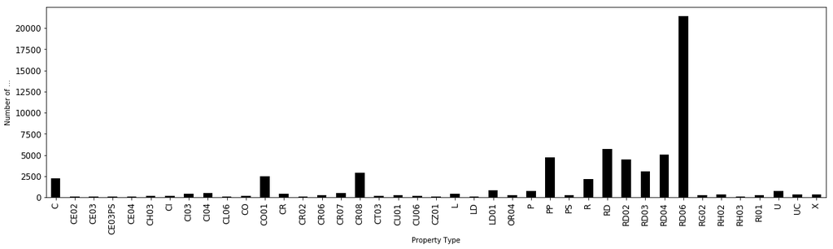

**`Selected Boroughs: London Wide`**

```python
# Just get list of labels for inspecting add base building schema types?
#labels = df_ldd_Filter1['ClassificationCode'].value_counts().reset_index(name="count").query("count > 50")
#labels = df_ldd_Filter1['class_label'].unique()

printmd('<br><br><b>`Number and Type of Properties Built Since 2004`</b> &#9663;<br><br>')
plotdat_label(df_filter_geo,'ClassificationCode')
printmd("<b>`Selected Boroughs:" + str(Borough_Selection) + '`</b><br><br><br><br>')

printmd('<br><br><b>`London Wide Comparison`</b> &#9663;<br><br>')
plotdat_label(df_ldd,'ClassificationCode')
printmd("<b>`Selected Boroughs: London Wide`</b><br><br><br><br>")
```

##### Comments

```python
%%capture
#Panda .loc warning
df_ldd_Filter_gen = df_filter_geo
df_ldd_Filter_gen.loc[:,'class_label'] = df_filter_geo['ClassificationCode'].astype(str).str[0]
df_ldd_Filter_gen_lon = df_ldd
df_ldd_Filter_gen_lon.loc[:,'class_label'] = df_ldd['ClassificationCode'].astype(str).str[0]
```

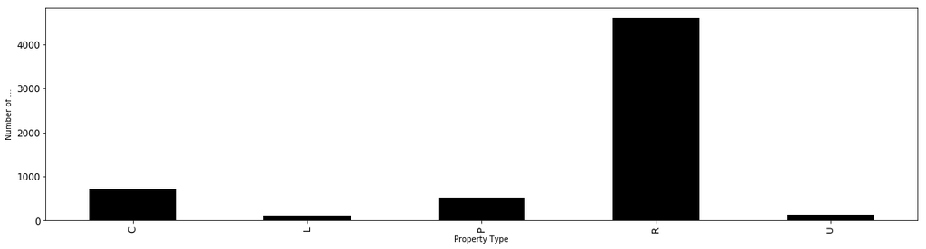

**`Selected Boroughs:('Brent', 'Croydon', 'Tower Hamlets')`**

**`London Wide Comparison`** ▿

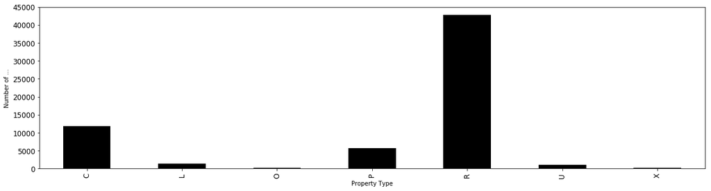

**`Selected Boroughs: London Wide`**

```python
printmd('<br><br><b>`Number and Type of Properties Grouped by Secondary Class`</b> &#9663;<br><br>')
plotdat_label(df_ldd_Filter_gen,'class_label')
printmd("<b>`Selected Boroughs:" + str(Borough_Selection) + '`</b><br><br><br><br>')

printmd('<br><br><b>`London Wide Comparison`</b> &#9663;<br><br>')
plotdat_label(df_ldd_Filter_gen_lon,'class_label')
printmd("<b>`Selected Boroughs: London Wide`</b><br><br><br><br>")
```

### Drill down into Secondary Class

**`Number and Type of Properties Grouped by Primary Class`** ▿

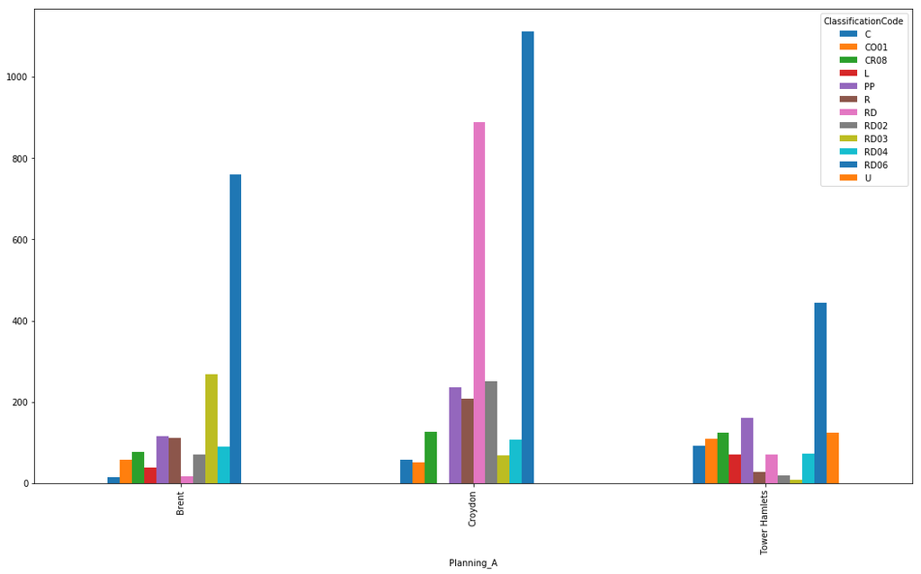

**`Selected Boroughs:('Brent', 'Croydon', 'Tower Hamlets')`**

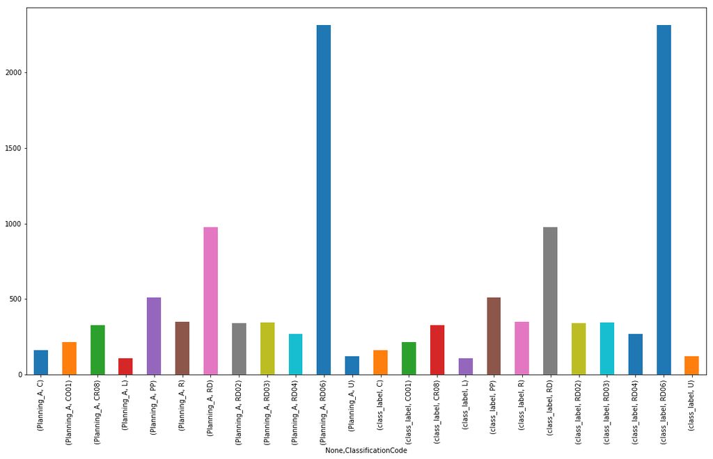

```python
printmd('<br><br><b>`Number and Type of Properties Grouped by Primary Class`</b> &#9663;<br><br>')
df_ldd_Filter2 = df_filter_geo[['Planning_A','ClassificationCode','class_label']]
df_ldd_Filter2 =  df_ldd_Filter2.groupby('ClassificationCode').filter(lambda x : len(x)>100)
df2 = df_ldd_Filter2.groupby(['Planning_A', 'ClassificationCode'])['Planning_A'].count().unstack('ClassificationCode').fillna(0)
df2.plot(kind='bar', figsize=(18, 10));
plt.show();
printmd("<b>`Selected Boroughs:" + str(Borough_Selection) + '`</b><br><br><br><br>')

printmd('<br><br><b>`London Wide Primary Class Comparison`</b> &#9663;<br><br>')
df_ldd_Filter3 = df_filter_geo[['Planning_A','ClassificationCode','class_label']]
df_ldd_Filter3 =  df_ldd_Filter3.groupby('ClassificationCode').filter(lambda x : len(x)>100)
df3 = df_ldd_Filter3.groupby('ClassificationCode').count().unstack('ClassificationCode').fillna(0)
df3.plot(kind='bar', figsize=(18, 10));
printmd("<b>`Selected Boroughs: London Wide`</b><br><br><br><br>")

#plotdat_label(df_ldd_Filter_gen_lon,'ClassificationCode')
```

### Inspect Location and Distribution of Address Types:

To Do: Map Legend

**`X and Y Locations of London New Build Development Type Since 2004`** ▿

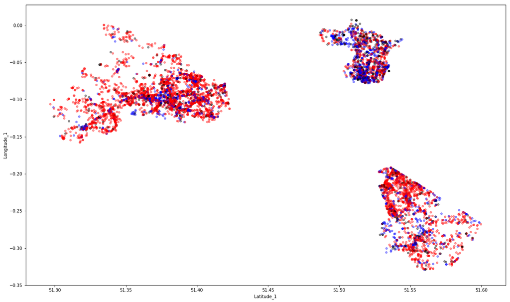

```python
printmd('<br><b>`X and Y Locations of London New Build Development Type Since 2004`</b> &#9663;<br><br>')
#colors = {'D':'red', 'E':'blue', 'F':'green', 'G':'black'}
colors = {'R':'red', 'O':'black', 'C':'blue', 'P':'black', 'L':'black', 'Z':'black', 'U':'black', 'X':'black'}

bubba = df_filter_geo.plot(kind='scatter',x='Latitude_1',y='Longitude_1',
                   c=df_filter_geo['class_label'].apply(lambda x: colors[x]), alpha=0.4, figsize=(20,12));
```

# 4 - Auxiliary Class Descriptive Filters

##### Get, Join and Check Auxilary Data :

> For convenience we retain the Acorn CACI, UK Census, Place Pulse and other Auxillary Property Descriptors in a seperate file to avoid loading up too much data. Our initial exploration of the data in search of suitable Labels for the CNN Classification Task will focus on the LDD and OS Addressbase and their Property/Address Classification schemas.

```python
#ACORN
#Load CSV
#Includes stripping for NULLs
df_acorn = pd.read_csv('/Users/anthonysutton/ml2/_ACORN_EXPLORER/ACORN_LONDON_ONLY.csv',  sep=',',
                           error_bad_lines=False, index_col=False,  na_values=['.'], encoding="ISO-8859-1")
#Join the 2 x tables
df_ldd_acorn_join = pd.merge(df_ldd_ab_sch_join, df_acorn, on='Postcode_Join' , how='left')
df_ldd_acorn_join.shape
df_ldd_acorn_join.head(1)
```

```
(66284, 111)
```

|  | UQ_ID | OBJECTID | TempID | Point_X | Point_Y | F1 | Planning_A | Borough_Re | Current_pe | Permission | Decision_A | Developmen | Scheme_Nam | Site_Name_ | Subdivisio | Primary_St | Secondary | Post_Code | Ward | Easting | Northing | Permissi_1 | Permissi_2 | Date_work | Started_Fi | Date_const | Completed | Date_permi | Lapsed_Fin | … |
| --- | --- | --- | --- | --- | --- | --- | --- | --- | --- | --- | --- | --- | --- | --- | --- | --- | --- | --- | --- | --- | --- | --- | --- | --- | --- | --- | --- | --- | --- | --- |
| 0 | 1 | 346 | 4187 | 552961 | 177195 | 4188 | Bexley | 14/00238/FUL | Completed | Full | Borough | Two storey side extension to provide a one bedroom annexe |  | Lower Farm |  | Wallhouse Road |  | DA8 2JY | NORTH END | 552961 | 177195 | 2.010000e+13 | FY2014 | 2.020000e+13 | FY2015 | 2.020000e+13 | FY2016 | 2.020000e+13 | FY2017 | … |

```python
df_acorn.columns
```

```
Index(['Unnamed: 0', 'Postcode_Join', 'Postcode', 'Large User', 'Deleted',
       'Acorn Category', 'Acorn Group', 'Acorn Type', 'Description'],
      dtype='object')
```

### CACI ACORN

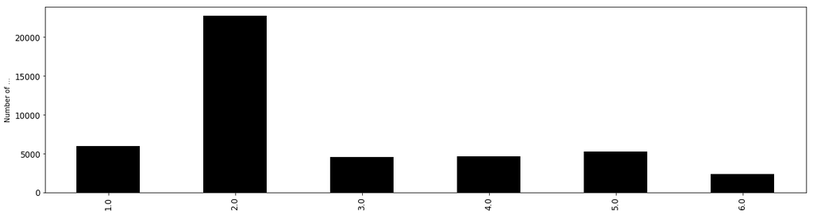

```python
plotdat(df_ldd_acorn_join,'Acorn Category')
```

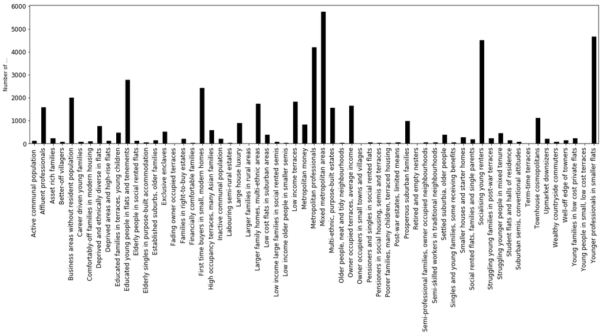

```python
plotdat(df_ldd_acorn_join,'Description')
```

**`Number and Type of Properties Grouped by Primary Class`** ▿

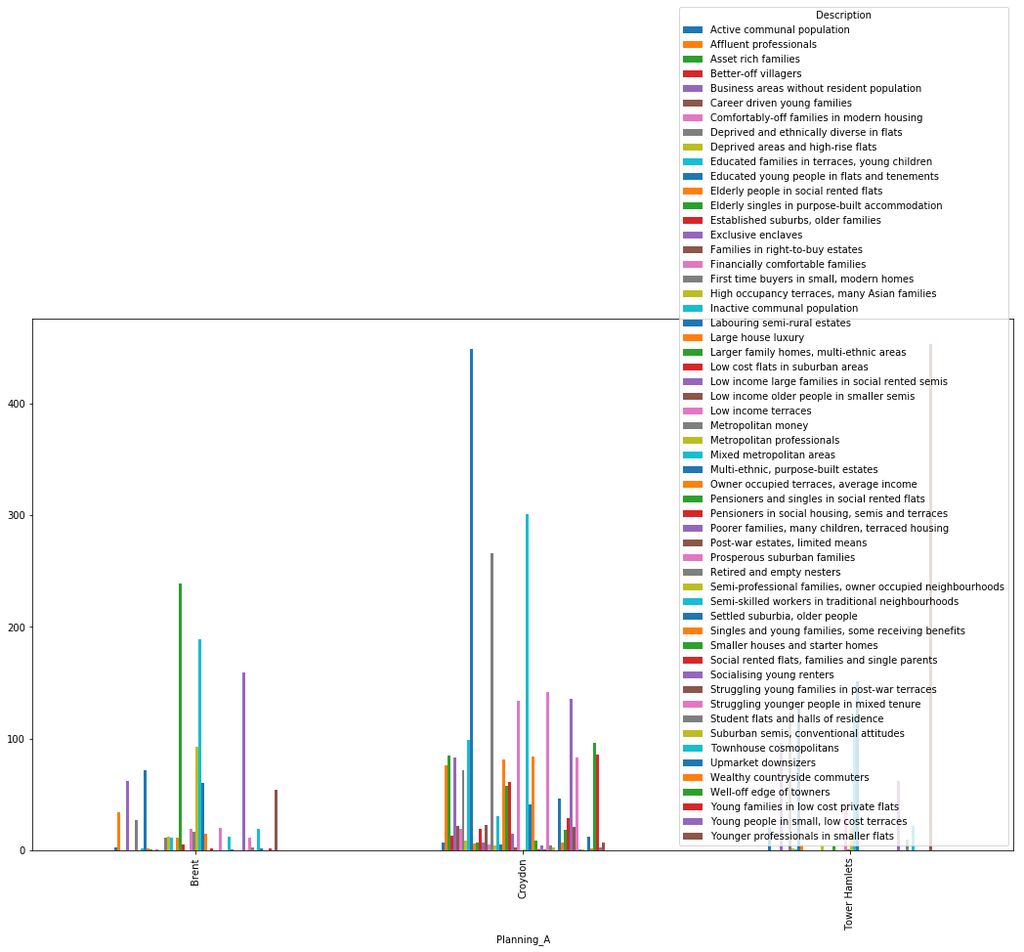

**`Selected Boroughs:('Brent', 'Croydon', 'Tower Hamlets')`**

```python
printmd('<br><br><b>`Number and Type of Properties Grouped by Primary Class`</b> &#9663;<br><br>')
df_ldd_acorn_join_filter = df_ldd_acorn_join[['Planning_A','ClassificationCode','Description']]
df_ldd_acorn_join_filter = df_ldd_acorn_join_filter.loc[df_ldd_acorn_join_filter['Planning_A'].isin(Borough_Selection)]
#df_ldd_acorn_join_filter =  df_ldd_acorn_join_filter.groupby('ClassificationCode').filter(lambda x : len(x)>100)
df4 = df_ldd_acorn_join_filter.groupby(['Planning_A', 'Description'])['Planning_A'].count().unstack('Description').fillna(0)
df4.plot(kind='bar', figsize=(18, 10));
plt.show();
printmd("<b>`Selected Boroughs:" + str(Borough_Selection) + '`</b><br><br><br><br>')
```

TO DO: Join Acorn to Class_Label & why isnt this stacking with Classification Codes

**`Number and Type of Properties Grouped by Primary Class`** ▿

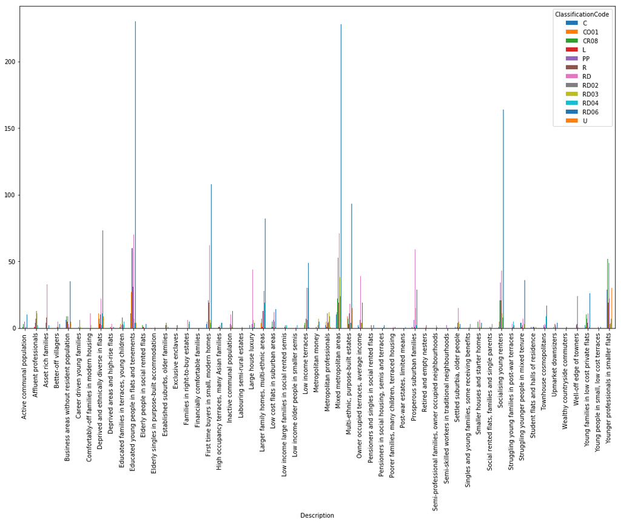

```python
printmd('<br><br><b>`Number and Type of Properties Grouped by Primary Class`</b> &#9663;<br><br>')
df_ldd_acorn_join_filter = df_ldd_acorn_join[['Planning_A','ClassificationCode','Description']]
df_ldd_acorn_join_filter = df_ldd_acorn_join_filter.loc[df_ldd_acorn_join_filter['Planning_A'].isin(Borough_Selection)]
df_ldd_acorn_join_filter =  df_ldd_acorn_join_filter.groupby('ClassificationCode').filter(lambda x : len(x)>100)
df4 = df_ldd_acorn_join_filter.groupby([ 'Description', 'ClassificationCode'])['Description'].count().unstack('ClassificationCode').fillna(0)
df4.plot(kind='bar', figsize=(18, 10));
plt.show();
printmd("<b>`Selected Boroughs: London Wide`</b><br><br><br><br>")
```

### PTAL zone by Development Type

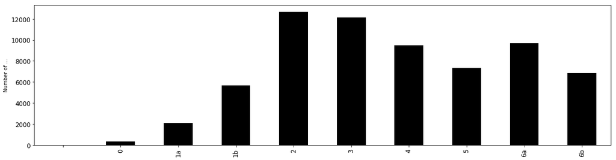

**`Selected Boroughs: London Wide`**

**`Number of New Build by PTAL Zone and by Property Type`** ▿

**`Selected Boroughs: London Wide`**

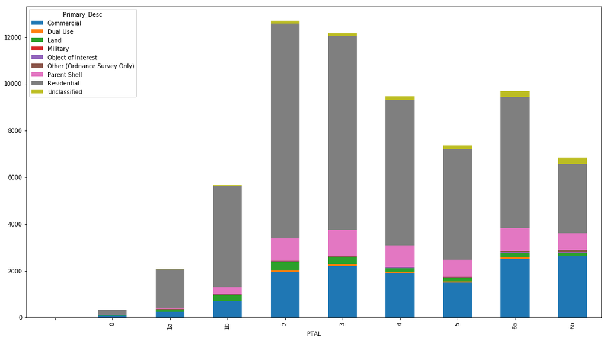

```python
#df_ldd_ptal_filter = df_ldd.loc[df_ldd['Planning_A'].isin(Borough_Selection)]

printmd('<br><br><b>Number of New Build by PTAL Zone  ' + str(Borough_Selection) +  'by PTAL Zone`</b> &#9663;<br><br>')
plotdat(df_ldd,'PTAL')
printmd("<b>`Selected Boroughs: London Wide`</b><br><br><br><br>")

#printmd('<br><br><b>`Number of New Build by PTAL Zone and by Property Type`</b> &#9663;<br><br>')
#df_ptal = df_ldd_ptal_filter.groupby(['PTAL', 'ClassificationCode'])['PTAL'].count().unstack('ClassificationCode').fillna(0)
#fig = df_ptal.plot(kind='bar', stacked=True, figsize=(18, 10));
#fig.savefig('Workflow/Ptal.png')
#printmd("<b>`Selected Boroughs: London Wide`</b><br><br><br><br>")
#df2.plot(kind='bar', figsize=(18, 10));

printmd('<br><br><b>`Number of New Build by PTAL Zone and by Property Type`</b> &#9663;<br><br>')
df_ptal = df_ldd_acorn_join.groupby(['PTAL', 'Primary_Desc'])['PTAL'].count().unstack('Primary_Desc').fillna(0)
fig = df_ptal.plot(kind='bar', stacked=True, figsize=(18, 10));
#fig.savefig('Workflow/Ptal.png')
printmd("<b>`Selected Boroughs: London Wide`</b><br><br><br><br>")
#df2.plot(kind='bar', figsize=(18, 10));
```

### PTAL zone by Development Type - Selected Boroughs

**Number of Developments by PTAL Zone ('Brent', 'Croydon', 'Tower Hamlets') by PTAL Zone`** ▿

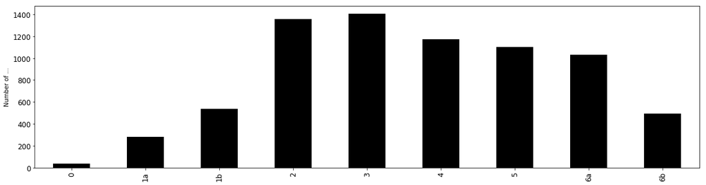

**`Selected Boroughs: ('Brent', 'Croydon', 'Tower Hamlets') `**

**`Number of New Build by PTAL Zone and by Property Type`** ▿

**`Selected Boroughs: London Wide`**

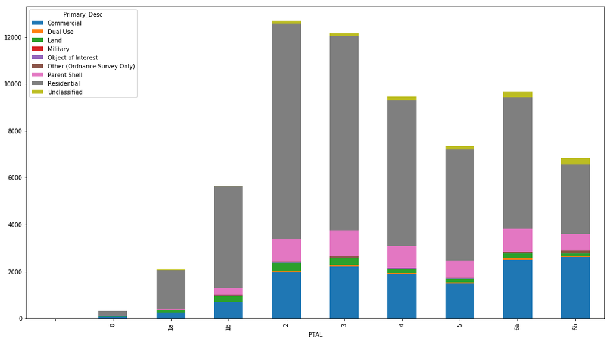

```python
df_ldd_ptal_filter = df_ldd.loc[df_ldd['Planning_A'].isin(Borough_Selection)]

printmd('<br><br><b>Number of Developments by PTAL Zone  ' + str(Borough_Selection) +  ' by PTAL Zone`</b> &#9663;<br><br>')
plotdat(df_ldd_ptal_filter,'PTAL')
printmd("<b>`Selected Boroughs: " + str(Borough_Selection) +  " `</b><br><br><br><br>")

printmd('<br><br><b>`Number of New Build by PTAL Zone and by Property Type`</b> &#9663;<br><br>')
df_ptal = df_ldd_acorn_join.groupby(['PTAL', 'Primary_Desc'])['PTAL'].count().unstack('Primary_Desc').fillna(0)
fig = df_ptal.plot(kind='bar', stacked=True, figsize=(18, 10));
#fig.savefig('Workflow/Ptal.png')
printmd("<b>`Selected Boroughs: London Wide`</b><br><br><br><br>")
#df2.plot(kind='bar', figsize=(18, 10));
```

**`Number of New Build in London by PTAL Level`** ▿

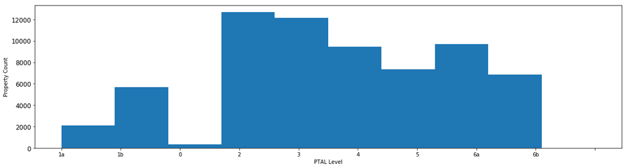

```python
printmd('<br><br><b>`Number of New Build in London by PTAL Level`</b> &#9663;<br><br>')
np_matrix = df_ldd_acorn_join[['PTAL']].values
plt.figure(figsize=(20,5))
plt.hist(np_matrix)
plt.ylabel('Property Count')
plt.xlabel('PTAL Level')
plt.yticks(fontsize=12)
printmd("<br>")
printmd("<br>")
plt.show();
```

### CREATE NEW LONDON vs OLD LONDON LABELS

```python
df_non_ldd = pd.read_csv('/Users/anthonysutton/ml2/_DATA_LABELS/LDD_STORE/LDD_MODEL/nonLDD.csv',  sep=',',
                           error_bad_lines=False, index_col=False,
                         usecols = ['Field1', 'Postcode', 'SubBuildingName', 'BuildingName',   'ClassificationCode'],
                         na_values=['.'], encoding="ISO-8859-1")
```

```python
# Get Image Names from the Non LDD Acorn Street View Download Run
final_acorn_label = pd.read_csv('/Users/anthonysutton/ml2/_ACORN_EXPLORER/final_acorn_label_upload9_noblank.csv',  sep=',',
                           error_bad_lines=False, index_col=False,  na_values=['.'], encoding="ISO-8859-1")
df_non_ldd.rename(columns={'Postcode':'Postcode_Join'}, inplace=True)
```

```python
df_non_ldd.head(1)
```

|  | Field1 | Postcode_Join | SubBuildingName | BuildingName | ClassificationCode |
| --- | --- | --- | --- | --- | --- |
| 0 | 237373 | BR11AA | FLAT 18 | HENRY HOUSE | RD06 |

```python
#Join
#df_ldd_acorn_label_join = pd.merge(df_non_ldd, final_acorn_label, on='Postcode_Join' , how='left')
```

```python
#df_ldd_acorn_label_join.shape
#df_ldd_acorn_label_join.head(100)
```

# 5 - London Wide Maps and Aggregate Data Visualisations

### Bringing it all Together

```python
#Get permission dates from Master
d_ldd_dates= pd.read_csv('/Users/anthonysutton/ml2/_DATA_LABELS/LDD_STORE/LDD_MODEL/LDD_Master.csv', sep=',',
                           error_bad_lines=False, index_col=False,  na_values=['.'], encoding="ISO-8859-1")

#Join
df_ldd_acorn_join = pd.merge(df_ldd, df_acorn, on='Postcode_Join' , how='left')
df_ldd_acorn_join.shape
df_ldd_acorn_join.head(1)

#Join
df_ldd_acorn_dates_join = pd.merge(df_ldd_acorn_join, d_ldd_dates[['Index_Column_Key', 'Commence_Date', 'Completion_Date', 'Permission_Date']], left_on='TempID' , right_on='Index_Column_Key', how='left')
df_ldd_acorn_dates_join.shape
df_ldd_acorn_dates_join.head(1)



date=pd.to_datetime(df_ldd_acorn_dates_join['Completion_Date'])
print (date.min())
print (date.max())
t_delta=(date-date.min()).astype('timedelta64[D]')
df_ldd_acorn_dates_join['days']=t_delta
df_ldd_acorn_dates_join.head(1)


#Ensure Properties are Building Completions
# Add this to image processing or data model build

#df_ldd_Filter3 = df_ldd_Filter3[df_ldd_Filter3['Completion_Date'] > '01/01/2015']
```

[output not shown]

|  | UQ_ID | OBJECTID | TempID | Point_X | Point_Y | F1 | Planning_A | Borough_Re | Current_pe | Permission | Decision_A | Developmen | Scheme_Nam | Site_Name_ | Subdivisio | Primary_St | Secondary | Post_Code | Ward | Easting | Northing | Permissi_1 | Permissi_2 | Date_work | Started_Fi | Date_const | Completed | Date_permi | Lapsed_Fin | … |
| --- | --- | --- | --- | --- | --- | --- | --- | --- | --- | --- | --- | --- | --- | --- | --- | --- | --- | --- | --- | --- | --- | --- | --- | --- | --- | --- | --- | --- | --- | --- |
| 0 | 1 | 346 | 4187 | 552961 | 177195 | 4188 | Bexley | 14/00238/FUL | Completed | Full | Borough | Two storey side extension to provide a one bedroom annexe |  | Lower Farm |  | Wallhouse Road |  | DA8 2JY | NORTH END | 552961 | 177195 | 2.010000e+13 | FY2014 | 2.020000e+13 | FY2015 | 2.020000e+13 | FY2016 | 2.020000e+13 | FY2017 | … |

```
(66284, 105)
```

|  | UQ_ID | OBJECTID | TempID | Point_X | Point_Y | F1 | Planning_A | Borough_Re | Current_pe | Permission | Decision_A | Developmen | Scheme_Nam | Site_Name_ | Subdivisio | Primary_St | Secondary | Post_Code | Ward | Easting | Northing | Permissi_1 | Permissi_2 | Date_work | Started_Fi | Date_const | Completed | Date_permi | Lapsed_Fin | … |
| --- | --- | --- | --- | --- | --- | --- | --- | --- | --- | --- | --- | --- | --- | --- | --- | --- | --- | --- | --- | --- | --- | --- | --- | --- | --- | --- | --- | --- | --- | --- |
| 0 | 1 | 346 | 4187 | 552961 | 177195 | 4188 | Bexley | 14/00238/FUL | Completed | Full | Borough | Two storey side extension to provide a one bedroom annexe |  | Lower Farm |  | Wallhouse Road |  | DA8 2JY | NORTH END | 552961 | 177195 | 2.010000e+13 | FY2014 | 2.020000e+13 | FY2015 | 2.020000e+13 | FY2016 | 2.020000e+13 | FY2017 | … |

```
2006-01-04 00:00:00
2018-12-04 00:00:00
```

|  | UQ_ID | OBJECTID | TempID | Point_X | Point_Y | F1 | Planning_A | Borough_Re | Current_pe | Permission | Decision_A | Developmen | Scheme_Nam | Site_Name_ | Subdivisio | Primary_St | Secondary | Post_Code | Ward | Easting | Northing | Permissi_1 | Permissi_2 | Date_work | Started_Fi | Date_const | Completed | Date_permi | Lapsed_Fin | … |
| --- | --- | --- | --- | --- | --- | --- | --- | --- | --- | --- | --- | --- | --- | --- | --- | --- | --- | --- | --- | --- | --- | --- | --- | --- | --- | --- | --- | --- | --- | --- |
| 0 | 1 | 346 | 4187 | 552961 | 177195 | 4188 | Bexley | 14/00238/FUL | Completed | Full | Borough | Two storey side extension to provide a one bedroom annexe |  | Lower Farm |  | Wallhouse Road |  | DA8 2JY | NORTH END | 552961 | 177195 | 2.010000e+13 | FY2014 | 2.020000e+13 | FY2015 | 2.020000e+13 | FY2016 | 2.020000e+13 | FY2017 | … |

```python
#with pd.option_context('display.max_rows', None, 'display.max_columns', 3):
#    df_ldd_acorn_dates_join['ClassificationCode'].value_counts()
```

## AB Address Class Heat Map by London Borough:

```python
#with pd.option_context('display.max_rows', None, 'display.max_columns', 3):
#    df_ldd_acorn_dates_join['Ward'].value_counts()
df_ldd_acorn_dates_join['Proposed_Total_Residential_Units'].max()
```

```
12898
```

```python
def types_districts(area,per):

    # Group by  type and district
    area_per_type=area.groupby('ClassificationCode').Planning_A.value_counts(sort=True)
    t=area_per_type.unstack().fillna(0)

    # Sort by boro sum
    area_sum=t.sum(axis=0)
    area_sum.sort_index(ascending=False)
    t=t[area_sum.index]

    # Filter by count per district
    area_sum=t.sum(axis=1)
    area_sum.sort_index()

    # Large number, so let's slice the data.
    p=np.percentile(area_sum,per)
    ix=area_sum[area_sum>p]
    t=t.loc[ix.index]
    return t

t=types_districts(df_ldd_acorn_dates_join,96)
```

```python
#from IPython.core.display import display, HTML
#display(HTML("<style>.container { width:100% !important; }</style>"))

t
```

| Planning_A ClassificationCode | Barking and Dagenham | Barnet | Bexley | Brent | Bromley | Camden | City of London | Croydon | Ealing | Enfield | Greenwich | Hackney | Hammersmith and Fulham | Haringey | Harrow | Havering | Hillingdon | Hounslow | Islington | Kensington and Chelsea | Kingston upon Thames | Lambeth | Lewisham | London Legacy DC | Merton | Newham | Old Oak and Park Royal DC (OPDC) | Redbridge | Richmond upon Thames | … |
| --- | --- | --- | --- | --- | --- | --- | --- | --- | --- | --- | --- | --- | --- | --- | --- | --- | --- | --- | --- | --- | --- | --- | --- | --- | --- | --- | --- | --- | --- | --- |
| C | 9.0 | 99.0 | 45.0 | 15.0 | 0.0 | 276.0 | 0.0 | 57.0 | 150.0 | 37.0 | 0.0 | 102.0 | 110.0 | 31.0 | 25.0 | 13.0 | 0.0 | 8.0 | 293.0 | 27.0 | 5.0 | 297.0 | 147.0 | 5.0 | 3.0 | 7.0 | 1.0 | 15.0 | 27.0 | … |
| CO01 | 19.0 | 80.0 | 32.0 | 57.0 | 91.0 | 91.0 | 81.0 | 51.0 | 44.0 | 4.0 | 28.0 | 103.0 | 116.0 | 40.0 | 83.0 | 32.0 | 74.0 | 59.0 | 36.0 | 73.0 | 82.0 | 14.0 | 13.0 | 5.0 | 47.0 | 30.0 | 1.0 | 45.0 | 62.0 | … |
| CR08 | 31.0 | 90.0 | 106.0 | 77.0 | 93.0 | 120.0 | 18.0 | 126.0 | 111.0 | 30.0 | 69.0 | 131.0 | 98.0 | 149.0 | 32.0 | 54.0 | 49.0 | 63.0 | 46.0 | 71.0 | 73.0 | 65.0 | 68.0 | 2.0 | 65.0 | 77.0 | 2.0 | 103.0 | 91.0 | … |
| PP | 45.0 | 224.0 | 27.0 | 116.0 | 80.0 | 3.0 | 60.0 | 237.0 | 240.0 | 11.0 | 126.0 | 289.0 | 50.0 | 375.0 | 131.0 | 31.0 | 40.0 | 76.0 | 218.0 | 176.0 | 132.0 | 167.0 | 115.0 | 7.0 | 132.0 | 123.0 | 2.0 | 71.0 | 159.0 | … |
| RD | 4.0 | 69.0 | 11.0 | 18.0 | 0.0 | 548.0 | 0.0 | 888.0 | 267.0 | 693.0 | 20.0 | 116.0 | 282.0 | 84.0 | 104.0 | 30.0 | 0.0 | 46.0 | 224.0 | 60.0 | 23.0 | 947.0 | 434.0 | 3.0 | 1.0 | 222.0 | 0.0 | 23.0 | 77.0 | … |
| RD02 | 23.0 | 428.0 | 170.0 | 70.0 | 719.0 | 2.0 | 0.0 | 251.0 | 127.0 | 26.0 | 79.0 | 37.0 | 7.0 | 81.0 | 182.0 | 391.0 | 249.0 | 88.0 | 19.0 | 32.0 | 251.0 | 30.0 | 24.0 | 1.0 | 230.0 | 41.0 | 0.0 | 126.0 | 247.0 | … |
| RD03 | 68.0 | 247.0 | 130.0 | 268.0 | 145.0 | 2.0 | 2.0 | 68.0 | 209.0 | 19.0 | 113.0 | 35.0 | 27.0 | 68.0 | 100.0 | 188.0 | 321.0 | 96.0 | 18.0 | 46.0 | 92.0 | 54.0 | 29.0 | 1.0 | 144.0 | 19.0 | 0.0 | 79.0 | 126.0 | … |
| RD04 | 137.0 | 122.0 | 115.0 | 90.0 | 130.0 | 7.0 | 5.0 | 108.0 | 467.0 | 32.0 | 48.0 | 234.0 | 52.0 | 243.0 | 118.0 | 254.0 | 99.0 | 146.0 | 62.0 | 214.0 | 88.0 | 150.0 | 97.0 | 3.0 | 199.0 | 219.0 | 0.0 | 186.0 | 162.0 | … |
| RD06 | 142.0 | 1121.0 | 185.0 | 759.0 | 588.0 | 339.0 | 65.0 | 1111.0 | 965.0 | 610.0 | 366.0 | 1312.0 | 968.0 | 839.0 | 608.0 | 245.0 | 359.0 | 441.0 | 928.0 | 635.0 | 274.0 | 571.0 | 912.0 | 18.0 | 571.0 | 580.0 | 0.0 | 477.0 | 506.0 | … |

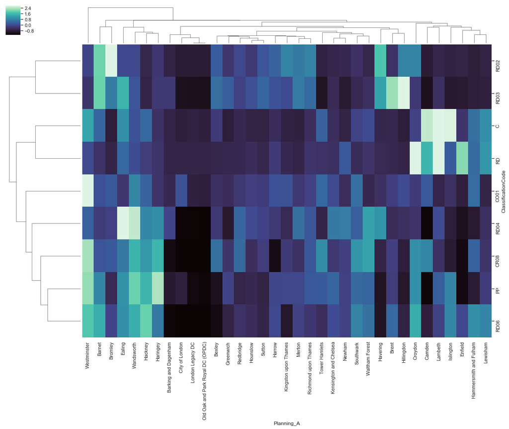

```python
sns.set(color_codes=True)
#g = sns.clustermap(t)
sns_plot = sns.clustermap(t, cmap="mako", robust=True, figsize=(20, 14), z_score=0)
sns_plot.savefig("dendo.png")
```

# 6 - Quick Spin CNN Trainer

- Run a quick CNN Transfer Learning Image Classification Task on Candidate Dataset
- For exploring and identifying suitable CNN Labeling Datasets
- Uses Tensorflow v 1.8 and Mobilenet_0.50 Transfer Learning Model for Speed vs Accuracy

```python
import datetime
import os
from __future__ import print_function
from ipywidgets import interact, interactive, fixed, interact_manual
import ipywidgets as widgets

import matplotlib.pyplot as plt
import matplotlib.image as mpimg

now = datetime.datetime.now()
```

```python
#Load MobNet Script Defaults
IMAGE_SIZE=224
ARCHITECTURE="mobilenet_0.50_" + str(IMAGE_SIZE)
SUMMARY_FOLDER = "tf_files/training_summaries"
RUN_FOLDER_NAME = now.isoformat()
STEP_SIZE = "1000"
TRAIN_IMAGE_FOLDER_NAME = "/Users/anthonysutton/ml2/_FINAL_SCRIPT_LIBRARY/LABELS/LABEL_RUN_1"
MODULE = "https://tfhub.dev/google/imagenet/mobilenet_v1_100_224/feature_vector/1"
```

```python
# View Previous Set Label Run Folder
directory = '/Users/anthonysutton/ml2/_FINAL_SCRIPT_LIBRARY/LABELS/LABEL_RUN_1'
for filename in os.listdir(directory):
      print(os.path.join(directory, filename))
```

```
/Users/anthonysutton/ml2/_FINAL_SCRIPT_LIBRARY/LABELS/LABEL_RUN_1/.DS_Store
/Users/anthonysutton/ml2/_FINAL_SCRIPT_LIBRARY/LABELS/LABEL_RUN_1/FLAT
/Users/anthonysutton/ml2/_FINAL_SCRIPT_LIBRARY/LABELS/LABEL_RUN_1/HOUSE
/Users/anthonysutton/ml2/_FINAL_SCRIPT_LIBRARY/LABELS/LABEL_RUN_1/INDUSTRIAL
/Users/anthonysutton/ml2/_FINAL_SCRIPT_LIBRARY/LABELS/LABEL_RUN_1/RETAIL
```

```python
#ENTER TEST IMAGE FOLDER
TEST_FOLDER_NAME = input("ENTER TEST IMAGE FOLDER LOCATION: ")
```

```
ENTER TEST IMAGE FOLDER LOCATION:
```

```python
# View Previous Set Label Run Folder
directory = '/Users/anthonysutton/ml2/tensorflow-for-poets-2/tf_files/train_runs/run_86'
for filename in os.listdir(directory):
      print(os.path.join(directory, filename))
```

```
/Users/anthonysutton/ml2/tensorflow-for-poets-2/tf_files/train_runs/run_86/bottlenecks
/Users/anthonysutton/ml2/tensorflow-for-poets-2/tf_files/train_runs/run_86/retrained_graph.pb
/Users/anthonysutton/ml2/tensorflow-for-poets-2/tf_files/train_runs/run_86/retrained_labels.txt
/Users/anthonysutton/ml2/tensorflow-for-poets-2/tf_files/train_runs/run_86/training_summaries
```

```python
#ENTER RUN SUMMARY LOG LOCATION
RUN_FOLDER_NAME = "run_" + input("Run Folder:")
```

```
Run Folder:
```

```python
#RUN_FOLDER_NAME = str(w2.value)
### Check Parameters
##print('para_run  ' + str(para_run))
print('IMAGE_SIZE  ' + str(IMAGE_SIZE))
print('STEP_SIZE  ' + str(STEP_SIZE))
print('ARCHITECTURE  ' + str(ARCHITECTURE))
print('MODULE  ' + str(MODULE))
print('TRAIN_IMAGE_FOLDER_NAME  ' + str(TRAIN_IMAGE_FOLDER_NAME))
print('RUN_FOLDER_NAME  ' + str(RUN_FOLDER_NAME))
```

```
IMAGE_SIZE  224
STEP_SIZE  1000
ARCHITECTURE  mobilenet_0.50_224
MODULE  https://tfhub.dev/google/imagenet/mobilenet_v1_100_224/feature_vector/1
TRAIN_IMAGE_FOLDER_NAME  /Users/anthonysutton/ml2/_FINAL_SCRIPT_LIBRARY/LABELS/LABEL_RUN_1
RUN_FOLDER_NAME  run_
```

```python
%run -i /Users/anthonysutton/ml2/tensorflow-for-poets-2/scripts/retrain.py \
  --bottleneck_dir=/Users/anthonysutton/ml2/tensorflow-for-poets-2/tf_files/train_runs/{RUN_FOLDER_NAME}/bottlenecks \
  --how_many_training_steps={STEP_SIZE} \
  --model_dir=/Users/anthonysutton/ml2/tensorflow-for-poets-2/tf_files/models/ \
  --summaries_dir=/Users/anthonysutton/ml2/tensorflow-for-poets-2/tf_files/train_runs/{RUN_FOLDER_NAME}/training_summaries/{ARCHITECTURE} \
  --output_graph=/Users/anthonysutton/ml2/tensorflow-for-poets-2/tf_files/train_runs/{RUN_FOLDER_NAME}/retrained_graph.pb \
  --output_labels=/Users/anthonysutton/ml2/tensorflow-for-poets-2/tf_files/train_runs/{RUN_FOLDER_NAME}/retrained_labels.txt \
  --architecture={ARCHITECTURE} \
  --image_dir={TRAIN_IMAGE_FOLDER_NAME}

print('jupyter --> done')
print(now.isoformat())
```

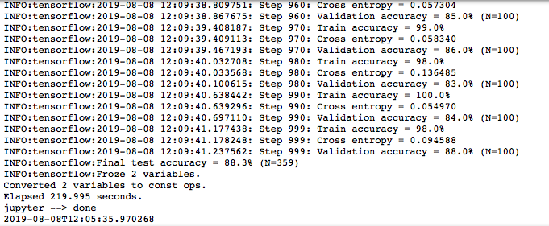